# DATA 622 Assignment 4: Mental Health, Clustering, and Suicide Prediction

Robert Welk and David Blumenstiel

10/30/2021

# Purpose

*For this assignment, we will be working with a very interesting mental health dataset from a real-life research project. All identifying information, of course, has been removed. The attached spreadsheet has the data (the tab name “Data”). The data dictionary is given in the second tab. You can get as creative as you want. The assignment is designed to really get you to think about how you could use different methods.*

The provided mental health dataset was uploaded to GitHub for ease of access and reproducability. First, it was imported into a dataframe. https://raw.githubusercontent.com/robertwelk/DATA622/main/ADHD_data.csv

```r
#packages
library(DataExplorer)
library(tidyverse)
library(corrplot)
library(scales)
library(mice)
library(caret)
library(GGally)
library(viridis)
library(plotly)
library(ggdendro)
library(ggpubr)
library(cluster)
library("dendextend")

df <- read.csv("https://raw.githubusercontent.com/robertwelk/DATA622/main/ADHD_data.csv", na.string="") # %>% as_tibble()
colnames(df)[1] <- "Initial"
```

# Exploratory Data Analysis

*Conduct a thorough Exploratory Data Analysis (EDA) to understand the dataset. (20 points)*

## Data Overview

There are 54 variables in the raw dataset.

**Data Dictionary**

-Sex: Male-1, Female-2

-Race: White-1, African American-2, Hispanic-3, Asian-4, Native American-5, Other or missing data -6

-ADHD self-report scale (multiple variables): Never-0, rarely-1, sometimes-2, often-3, very often-4

-Mood disorder questions(multiple variables): No-0, yes-1; question 3: no problem-0, minor-1, moderate-2, serious-3

-Individual substances misuse(multiple variables): no use-0, use-1, abuse-2, dependence-3

-Court Order: No-0, Yes-1

-Education: 1-12 grade, 13+ college

-History of Violence: No-0, Yes-1

-Disorderly Conduct: No-0, Yes-1

-Suicide attempt: No-0, Yes-1

-Abuse Hx: No-0, Physical (P)-1, Sexual (S)-2, Emotional (E)-3, P&S-4, P&E-5, S&E-6, P&S&E-7

-Non-substance-related Dx: 0 – none; 1 – one; 2 – More than one

-Substance-related Dx: 0 – none; 1 – one Substance-related; 2 – two; 3 – three or more

-Psychiatric Meds: 0 – none; 1 – one psychotropic med; 2 – more than one psychotropic med

Below are a couple basic plots of the dataset as a whole.

```r
# overview of data
str(df)
```

```
## 'data.frame':    175 obs. of  54 variables:
##  $ Initial           : chr  "JA" "LA" "MD" "RD" ...
##  $ Age               : int  24 48 51 43 34 39 41 48 44 27 ...
##  $ Sex               : int  1 2 2 1 1 2 2 1 2 2 ...
##  $ Race              : int  1 1 1 1 1 1 1 1 1 1 ...
##  $ ADHD.Q1           : int  1 3 2 3 4 2 2 2 3 2 ...
##  $ ADHD.Q2           : int  1 3 1 3 4 3 2 4 3 3 ...
##  $ ADHD.Q3           : int  4 4 2 2 2 1 1 3 3 4 ...
##  $ ADHD.Q4           : int  2 4 1 2 4 4 3 4 4 4 ...
##  $ ADHD.Q5           : int  3 5 3 4 4 3 4 3 4 4 ...
##  $ ADHD.Q6           : int  1 2 3 3 2 2 4 3 3 3 ...
##  $ ADHD.Q7           : int  1 2 3 2 3 3 2 1 3 4 ...
##  $ ADHD.Q8           : int  3 3 2 4 4 4 3 1 4 3 ...
##  $ ADHD.Q9           : int  2 2 0 4 4 4 3 4 3 2 ...
##  $ ADHD.Q10          : int  4 4 1 2 2 2 4 2 4 4 ...
```

[output cut: 40 more lines]

```r
introduce(df)
```

```
##   rows columns discrete_columns continuous_columns all_missing_columns
## 1  175      54                1                 53                   0
##   total_missing_values complete_rows total_observations memory_usage
## 1                  250            55               9450        56104
```

Above is a quick breakdown of the different variables. Except for the Initial variable (which will be removed prior to modeling), every variable is an integer (continuous). This doesn’t make too much sense for many of these variables, such as the ADHD and MD self report questions. While such variables often progress in the same direction (1<2<3), there is no real scale; these variables would be better described as categorical.

When it comes to missing data, most variables are completely intact, while only one variable (Psych Meds) is missing a significant amount (67%). Missing data will later be imputed.

## 1. Demographics

Below is an basic exploration of some demographic information: Age, Sex, Race, and Education.

```r
#table(df$Sex)
# variables that can be categorized as demographics
demographics <- c('Age', 'Race', 'Sex', 'Education')

# summary of demographics
df %>% dplyr::select(all_of(demographics)) %>%  summary()
```

```
##       Age             Race           Sex          Education
##  Min.   :18.00   Min.   :1.00   Min.   :1.000   Min.   : 6.0
##  1st Qu.:29.50   1st Qu.:1.00   1st Qu.:1.000   1st Qu.:11.0
##  Median :42.00   Median :2.00   Median :1.000   Median :12.0
##  Mean   :39.47   Mean   :1.64   Mean   :1.434   Mean   :11.9
##  3rd Qu.:48.00   3rd Qu.:2.00   3rd Qu.:2.000   3rd Qu.:13.0
##  Max.   :69.00   Max.   :6.00   Max.   :2.000   Max.   :19.0
##                                                 NA's   :9
```

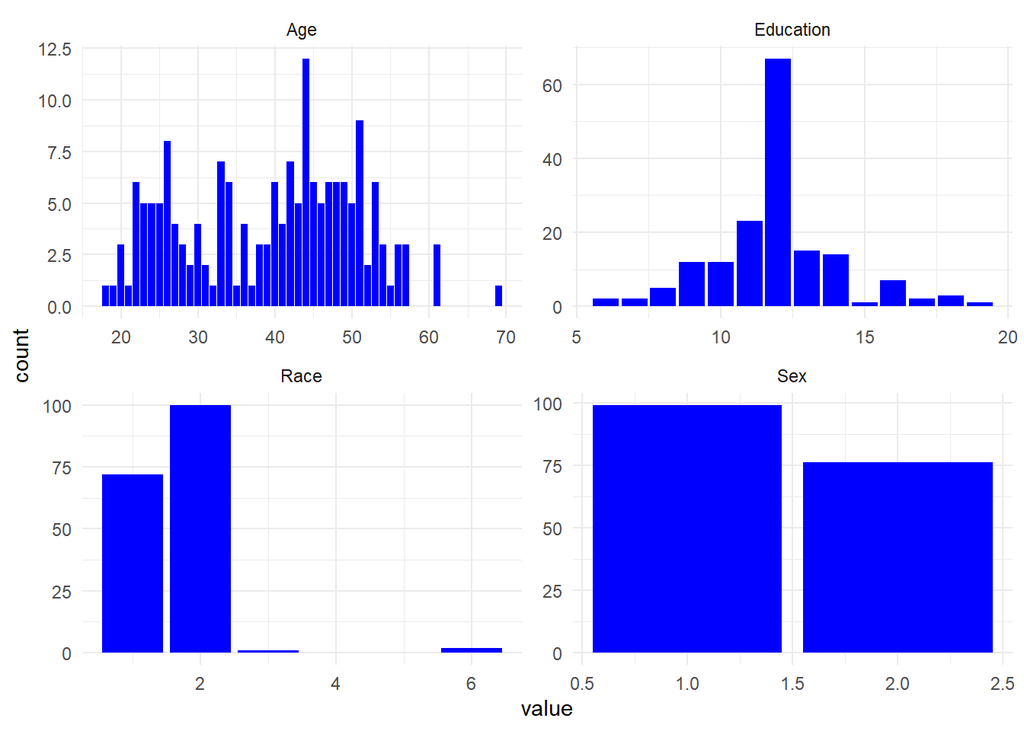

```r
#df %>% dplyr::select(all_of(demographics)) %>%  str


# get counts of each group
df %>%
  dplyr::select(all_of(demographics), Initial) %>%
  pivot_longer(-Initial) %>%
  ggplot(aes(x=value)) +
  geom_bar(stat="count", fill="blue") +
  facet_wrap(~name, scales="free") +
  theme_minimal()
```

```r
# Replace 2 (female) to 0 so that range is from 0 to 1
df$Sex[df$Sex==2] <- 0
```

*Age, Sex, Race, and Education*

- Ages range from 18 to 69 with a median of 42. This is older than the median age of the US population, 38 years, likely because this dataset excludes children (dataset >= 18 years).
- 12 years of education, high school completion, is the most common level of educational attainment. More participants had not completed high school than had a college education. Education levels ranged from 6 years to 19 years.
- African Americans were the most common ethnic group (100) followed by White (72). Other ethnic groups had few participants (3)
- There were more males (99) than females (76) in this dataset.

## 2. ADHD self-report

The raster plot below shows an aggregation of the number of counts for each question/response pair for the ADHD set.

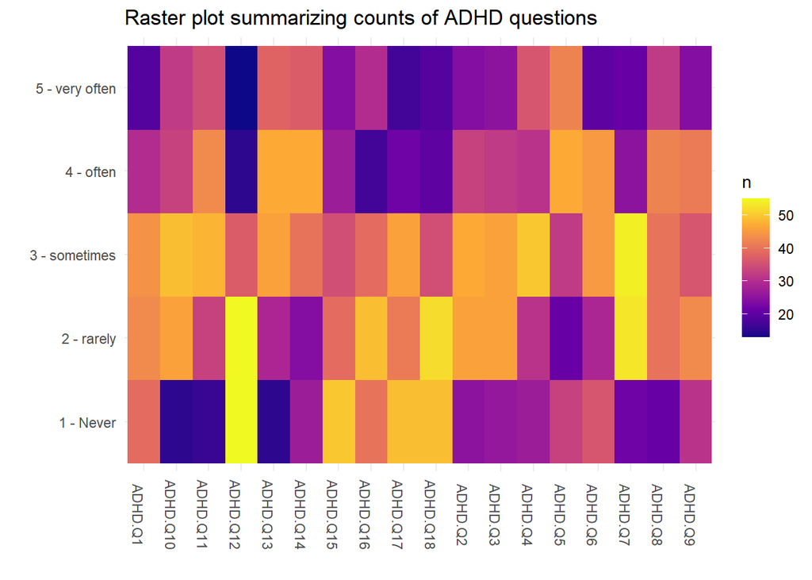

```r
# fix the invalid entry
df$ADHD.Q5[df$ADHD.Q5==5] <- 4
# raster plot of response counts
df %>%
  dplyr::select(starts_with('ADHD')) %>%
  pivot_longer(-ADHD.Total) %>%
  group_by(name) %>%
  count(val=factor(value)) %>%
  ggplot(aes(x=as.factor(name),y=val,fill=n)) +
  #geom_point(size=5)+
  geom_raster() +
  scale_fill_viridis_c(option = "plasma") +
  labs(y="",x="", title="Raster plot summarizing counts of ADHD questions")+
  scale_y_discrete(labels=c("1 - Never","2 - rarely","3 - sometimes","4 - often","5 - very often")) +
  theme_minimal() +
    theme(axis.text.x = element_text(angle = -90))
```

- Q.12 had responses that are different from the rest
- Q.7 had many one and twos
- Q.5 had an invalid entry (5) which was assumed to be (4) and replaced prior to plotting

## 3. Mood Disorder self-report

The raster plot below shows and aggregation of number of counts for each question/response pair for the mood disorder set.

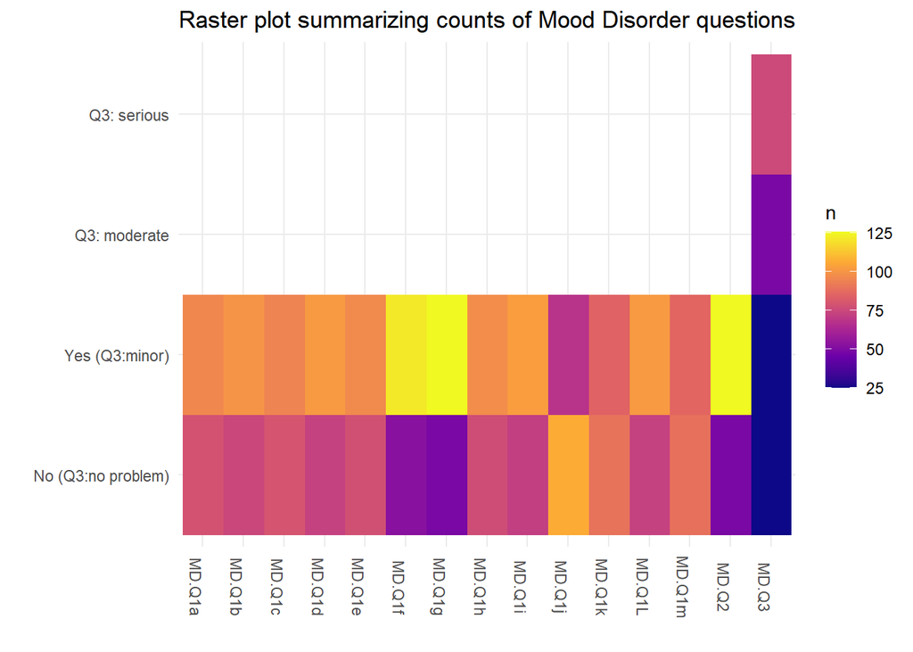

```r
df %>%
  dplyr::select(starts_with('MD')) %>%
  pivot_longer(-MD.TOTAL) %>%
  group_by(name) %>%
  count(val=factor(value)) %>%
  ggplot(aes(x=as.factor(name),y=val,fill=n)) +
  #geom_point(size=5)+
  geom_raster() +
  scale_fill_viridis_c(option = "plasma") +
  labs(y="",x="", title="Raster plot summarizing counts of Mood Disorder questions")+
  scale_y_discrete(labels=c("No (Q3:no problem)","Yes (Q3:minor)","Q3: moderate","Q3: serious")) +
  theme_minimal() +
    theme(axis.text.x = element_text(angle = -90))
```

Below is a density plot of the ADHD Total and MD Total variables; the cumulative score of all questions for both categories for each individual.

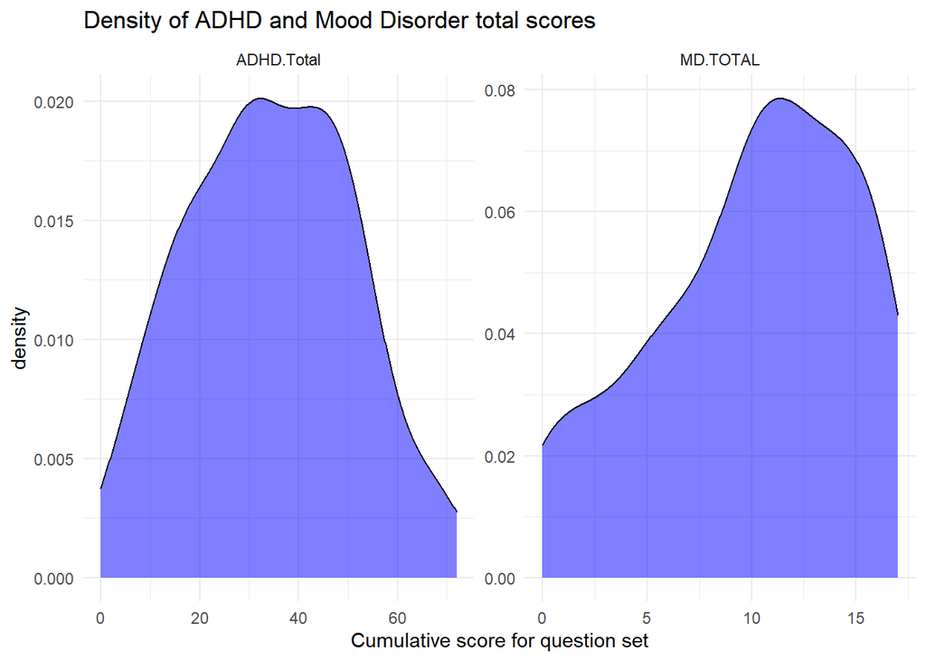

```r
# find the distribution of score
df %>%
  select(MD.TOTAL,ADHD.Total) %>%
  pivot_longer(everything()) %>%
  ggplot(aes(value))+
           geom_density(alpha=.5, fill="blue") +
           facet_wrap(~name, scale="free") +
           labs(x="Cumulative score for question set", title="Density of ADHD and Mood Disorder total scores")+
  theme_minimal()
```

- The distribution of ADHD Total is somewhat Gaussian (if perhaps a little right skewed), with a mean of 34.3 and a standard deviation of 16.7.
- This variable will likely be valuable for representing relative ADHD severity
- The MD Total variable is fairly left skewed, with individuals on the whole tending to report highly on the MD questions.
- This variable has a median of 11, and an IQR of 7.5.

## 4. Drug Use

Below is a plot of the 6 substance usage questions. Each substance is represented by a bar proportioned by how individuals use the substance.

*Substance Usage*

no use-0, use-1, abuse-2, dependence-3

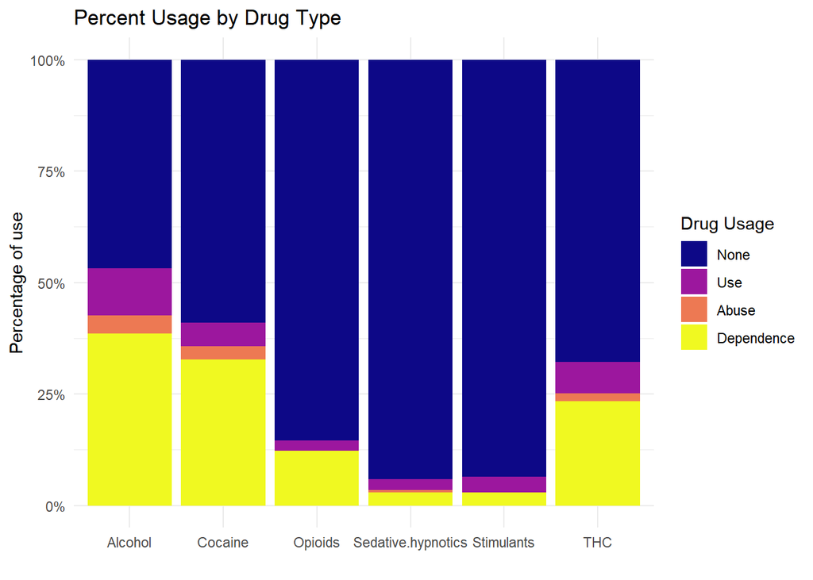

```r
na.omit(df[,40:45]) %>%
  dplyr::select(Alcohol, THC,Cocaine,Stimulants, Sedative.hypnotics,Opioids) %>%
  pivot_longer(everything()) %>%
  ggplot(aes(x=name,fill=as.factor(value))) +
  geom_bar(position = "fill") +
  scale_fill_viridis_d(name="Drug Usage", labels=c("None","Use", "Abuse","Dependence" ),option="plasma") +
  theme_minimal() +
  labs(x="",y='Percentage of use',title="Percent Usage by Drug Type")+
  scale_y_continuous(labels = scales::percent)
```

```r
q <- na.omit(df[,40:45])
q$DRUG_abuse <- as.integer(apply(q >= 2, 1, any))  #Drug abusers
q <- sum(q$DRUG_abuse)/length(q$DRUG_abuse)
```

- The most frequent response for all substances was ‘no use’, except for alcohol, which most of the participants had some level of usage
- Individuals were more likely to report dependence rather than use or abuse
- Alcohol was the most commonly abused/dependent drug, followed by Cocaine, then THC
- 76.6% of participants reported either abuse or dependence of one or more of these drugs. This seems rather high.

## 5. Legal Issues

Below are figures pertaining to ‘legal issues’: court orders, disorderly conduct, and history of violence

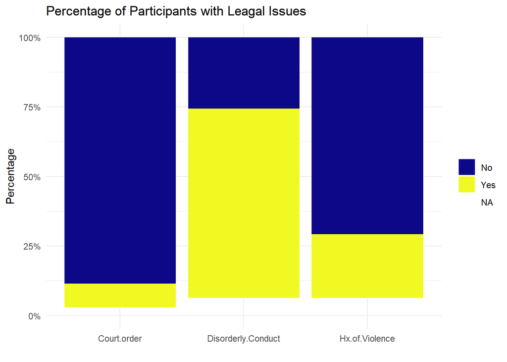

```r
# df %>%
#   dplyr::select(Court.order, Disorderly.Conduct, Hx.of.Violence ,Initial) %>%
#     pivot_longer(-c(Initial)) %>%
#   group_by(name, value) %>%
#   summarize(number=n())

df %>%
  dplyr::select(Court.order, Disorderly.Conduct, Hx.of.Violence) %>%
  pivot_longer(everything()) %>%
  ggplot(aes(x=name,fill=as.factor(value))) +
  geom_bar(position = "fill") +
  scale_fill_viridis_d(name="", labels=c("No","Yes"),option="plasma") +
  theme_minimal() +
  labs(x="",y='Percentage', title="Percentage of Participants with Leagal Issues") +
  scale_y_continuous(labels = scales::percent)
```

- Disorderly conduct was the most common legal issue with 119 of participants having one
- There were relatively few court orders (15)
- 40 had a history of violence

## 6. Abuse

Below is a bar-plot of abuse. This is a categorical variable with values referencing different types of abuse. These values follow as:

No-0, Physical (P)-1, Sexual (S)-2, Emotional (E)-3, P&S-4, P&E-5, S&E-6, P&S&E-7

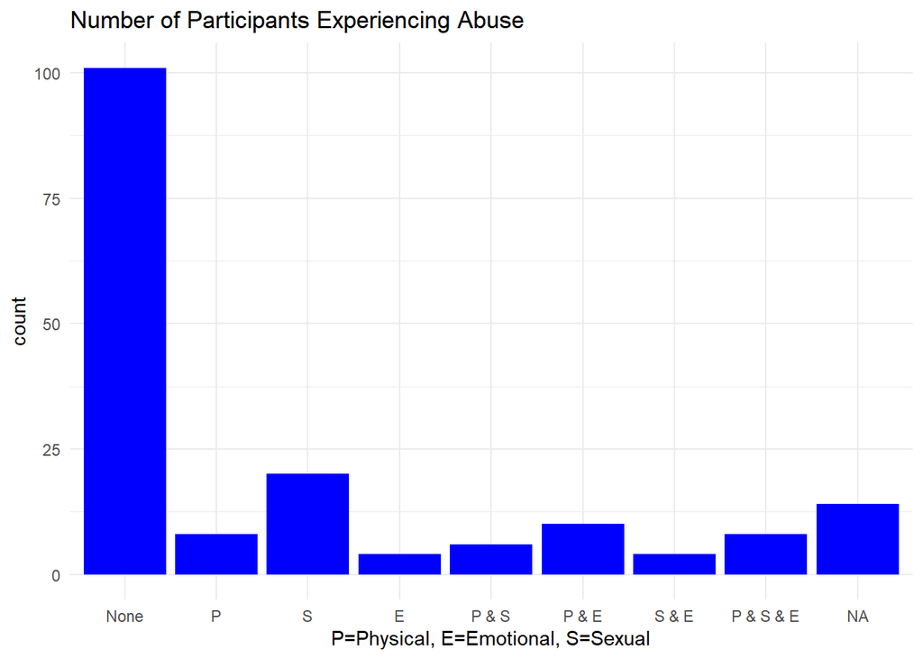

```r
df %>%
  dplyr::select(Abuse) %>%
  mutate(Abuse=factor(Abuse)) %>%
  ggplot(aes(Abuse)) +
  geom_bar(stat="count", fill="blue") +
  scale_x_discrete(labels=c("None", "P", "S", "E", "P & S", "P & E", "S & E", "P & S & E")) +
  theme_minimal() +
  labs(x="P=Physical, E=Emotional, S=Sexual", title="Number of Participants Experiencing Abuse")
```

- Most participants (101) had no history of abuse
- Sexual abuse was the second most common, followed by physical and emotional > physical > physical, emotional, and sexual

## 7. Medical Interventions

Below, the prevalence of substance and non-substance related diagnoses, along with (prescription) psychotropic medications are explored.

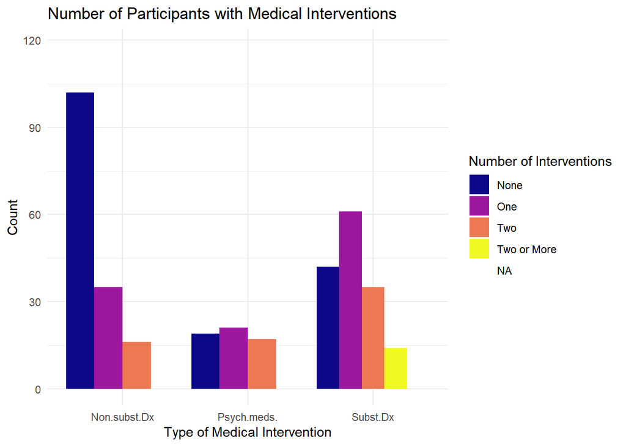

```r
df %>%
  dplyr::select(Subst.Dx,Non.subst.Dx,Psych.meds. ) %>%
  pivot_longer(everything()) %>%
  ggplot(aes(x=name,fill=as.factor(value))) +
  geom_bar(position="dodge") +
  scale_fill_viridis_d(name="Number of Interventions", labels=c("None","One","Two", "Two or More"),option="plasma") +
  theme_minimal() +
  labs(x="Type of Medical Intervention",y='Count',title="Number of Participants with Medical Interventions")
```

- Most participants had a substance diagnosis, many had 2 or more
- Most participants did not had a non substance diagnosis
- Participants were almost as likely to use 0, 1, or more than 1 psychotropic drugs, although the majority of the data is missing for this variable

## 8. Suicide

Suicide is the target variable for the the supervised learning section later on. Below, there are several different figures examining suicide attempts in respect to several different variables:

First we investigate how self-report relates to suicide. There is a scatter-plot of MD and ADHD totals colored by Suicide. Combinations of self-report associated with suicide attempt can be inferred. Also included are two bar-plots for the individual questions. For these figures, aggregate counts by groups of questions and responses was calculated as was the percentage of each group that had a suicide attempt. The top ten highest question/response pairs in terms of associated suicide attempt rate are given for the both the ADHD and Mood Disorder questionnaires.

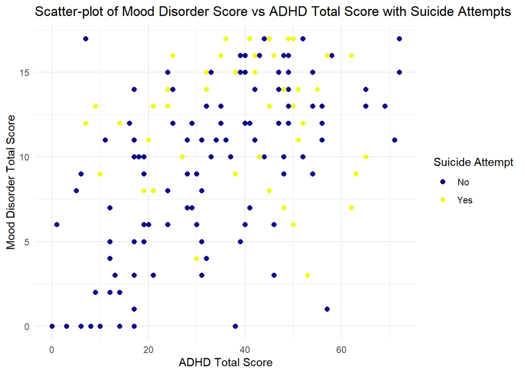

```r
# ADHD and MD
df %>%
  filter(!is.na(Suicide)) %>%
  ggplot(aes(x=ADHD.Total, y=MD.TOTAL, col=factor(Suicide))) +
  geom_point(size=2) +
  scale_color_viridis_d(name="Suicide Attempt", labels=c("No","Yes"),option="plasma") +
  labs(x="ADHD Total Score", y="Mood Disorder Total Score", title="Scatter-plot of Mood Disorder Score vs ADHD Total Score with Suicide Attempts") +
  theme_minimal()
```

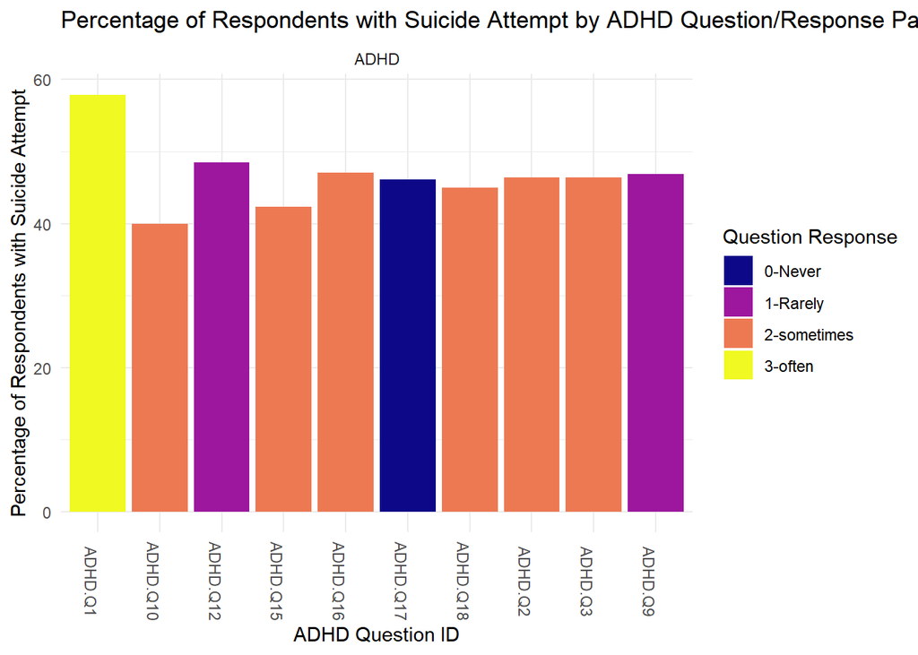

```r
# which questions/response pairs were most associated with suicide
df %>%
    filter(!is.na(Suicide)) %>%
  dplyr::select(starts_with('ADHD.Q'),Suicide) %>%
  pivot_longer(-Suicide) %>%
  group_by(name,Suicide) %>%
  count(val=factor(value)) %>%
  group_by(name,val) %>%
  mutate(suicide_per=prop.table(n)*100) %>%
  filter(Suicide==1, suicide_per > 30) %>%
  arrange(desc(suicide_per)) %>%
  head(n=10) %>%
  mutate(type="ADHD") %>%
    ggplot(aes(x=factor(name),y=suicide_per, fill=val)) +
    geom_bar(stat="identity", position="dodge") +
  theme_minimal()+
  scale_fill_viridis_d(name="Question Response", labels=c("0-Never","1-Rarely","2-sometimes", "3-often","4-very often"),option="plasma") +
    labs(x="ADHD Question ID",
         y="Percentage of Respondents with Suicide Attempt",
         title="Percentage of Respondents with Suicide Attempt by ADHD Question/Response Pair"
         )+
      theme(axis.text.x = element_text(angle = -90))+
  facet_wrap(~type, scales="free")
```

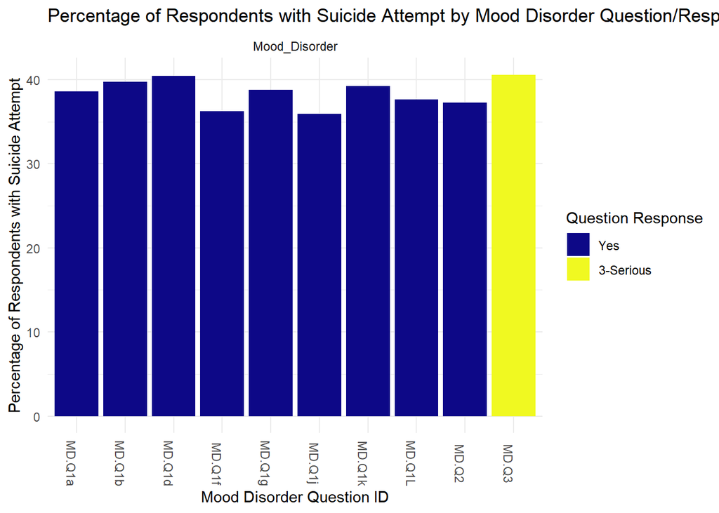

```r
df %>%
    filter(!is.na(Suicide)) %>%
  dplyr::select(starts_with('MD.Q'),Suicide) %>%
  pivot_longer(-Suicide) %>%
  group_by(name,Suicide) %>%
  count(val=factor(value)) %>%
  group_by(name,val) %>%
  mutate(suicide_per=prop.table(n)*100) %>%
  filter(Suicide==1, suicide_per > 30) %>%
  arrange(desc(suicide_per))%>%
  head(n=10) %>%
  mutate(type="Mood_Disorder") %>%

    ggplot(aes(x=factor(name),y=suicide_per, fill=val)) +
    geom_bar(stat="identity", position="dodge") +
  theme_minimal()+
  scale_fill_viridis_d(name="Question Response", labels=c("Yes","3-Serious"),option="plasma") +
    labs(x="Mood Disorder Question ID",
         y="Percentage of Respondents with Suicide Attempt",
         title="Percentage of Respondents with Suicide Attempt by Mood Disorder Question/Response Pair"
         )+
      theme(axis.text.x = element_text(angle = -90))+
  facet_wrap(~type, scales="free")
```

- 49 out of 162 participants (~30%) attempted a suicide
- Self-report scores above median are slightly associated with more of suicide attempts
- There were no attempted suicides for individuals with less than 30 ADHD Total in combination with less than 8 MD Total
- For the ADHD questions, highest levels of suicide attempt came across response types, with moderate responses (1 and 2) being more common than the extreme responses.
- For the Mood Disorder questions, responses of Yes for Q1 and Q2 and Serious for Q3 were the groups most associated with suicide

Below, suicide is examined in relation to sex, race, age, and educational attainment, first in a scatter-plot between Age and Education and next in a bar-plot of Race and Sex where group rate of suicide attempt is calculated.

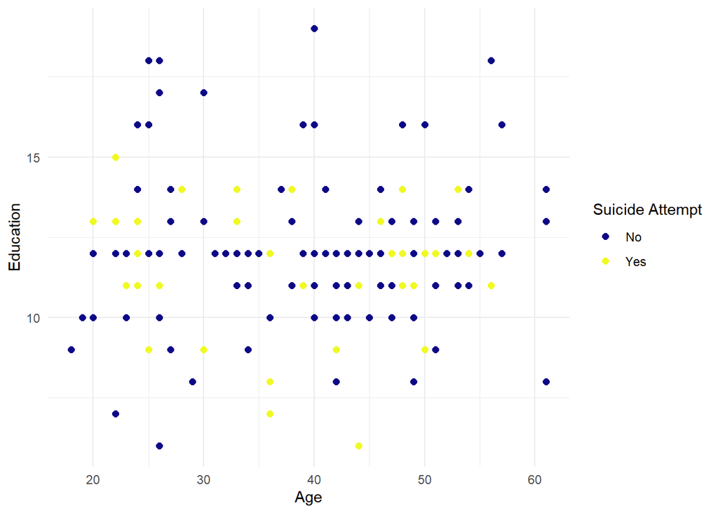

```r
# Demographics
df %>%
  filter(!is.na(Suicide)) %>%
  ggplot(aes(x=Age, y=Education, col=factor(Suicide))) +
  geom_point(size=2) +
  scale_color_viridis_d(name="Suicide Attempt", labels=c("No","Yes"),option="plasma") +
  theme_minimal()
```

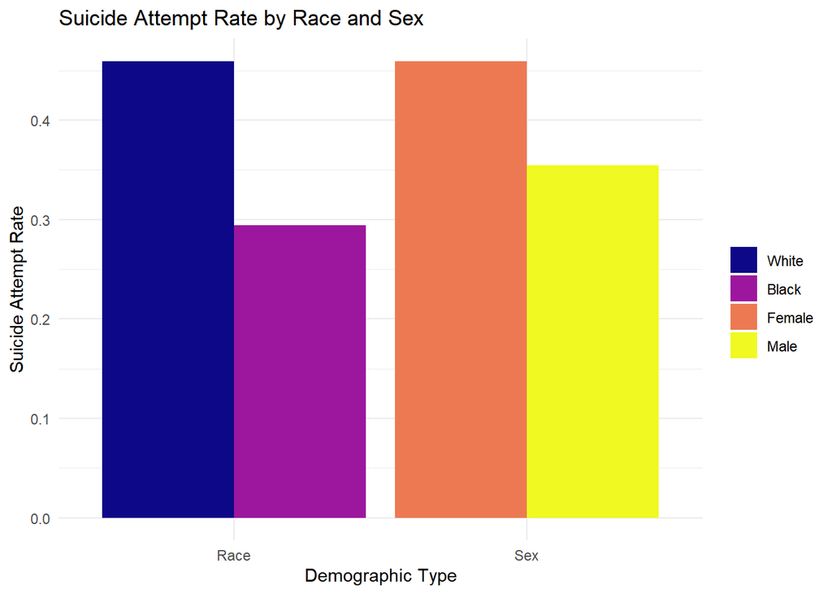

```r
tab <- df %>%
  filter(!is.na(Suicide)) %>%
  dplyr::select(Suicide,Race,Sex) %>%
  group_by(Race, Suicide,Sex) %>%
  count() %>%
  group_by(Race,Sex) %>%
  mutate(per=prop.table(n)) %>%
  filter(Suicide==1, Race != 6) %>%
  mutate(Race=factor(Race), Sex=factor(Sex))
levels(tab$Race) <- c("White","Black")
levels(tab$Sex) <- c("Female","Male")

tab %>%
  pivot_longer(c(Race,Sex)) %>%
  ggplot(aes(x=factor(name),y=per,fill=factor(value))) +
    geom_bar(stat="identity", position="dodge") +
  scale_fill_viridis_d(option="plasma", name="") +
  theme_minimal()+
  labs(x="Demographic Type",y="Suicide Attempt Rate", title="Suicide Attempt Rate by Race and Sex")
```

- Whites and females were more likely to attempt suicide
- Those with some college education (> 12 years) were less likely to attempt suicide. No participant with more than 15 years of education attempted suicide

Below, suicide in relation to substance use is examined.

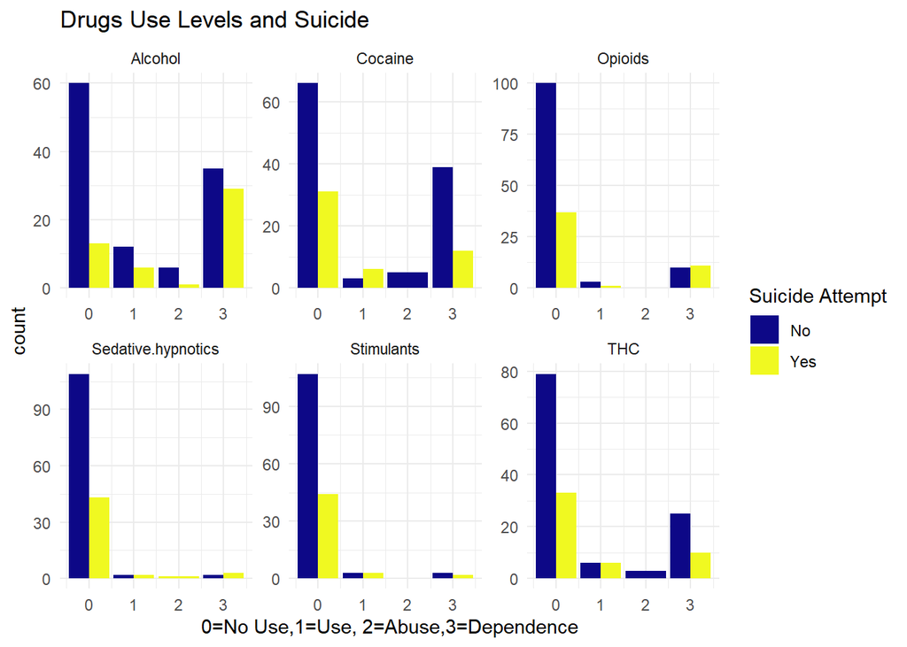

```r
# Drug use
df %>%
  filter(!is.na(Suicide)) %>%
  dplyr::select(Alcohol, THC,Cocaine,Stimulants, Sedative.hypnotics,Opioids,Suicide) %>%
  pivot_longer(-c(Suicide)) %>%
  ggplot(aes(value, fill=factor(Suicide))) +
  geom_bar(position="dodge") +
  scale_fill_viridis_d(name="Suicide Attempt", labels=c("No","Yes" ),option="plasma") +
  theme_minimal() +
  labs(x="0=No Use,1=Use, 2=Abuse,3=Dependence", title="Drugs Use Levels and Suicide") +
  facet_wrap(~name, scales="free")
```

Below, suicide in relation to legal issues and violence is examined.

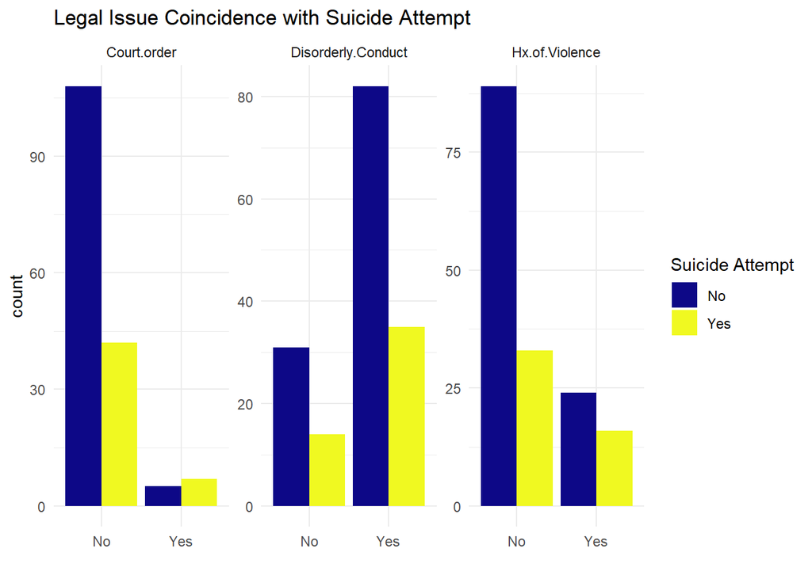

```r
# Legal issues
df %>% filter(!is.na(Suicide)) %>%
  dplyr::select(Court.order, Hx.of.Violence, Disorderly.Conduct ,Suicide) %>%
  pivot_longer(-c(Suicide)) %>%
  ggplot(aes(factor(value), fill=factor(Suicide))) +
  geom_bar(position="dodge") +
  scale_fill_viridis_d(name="Suicide Attempt", labels=c("No","Yes"),option="plasma") +
  scale_x_discrete(labels=c("No","Yes"))+
  labs(x="", title = 'Legal Issue Coincidence with Suicide Attempt')+
  theme_minimal()+
  facet_wrap(~name, scales="free")
```

- Suicide is more prevalent among those with a history of violence, or a court order.

Below, suicide in relation to legal issues and diagnoses and psychotropic prescriptions is examined.

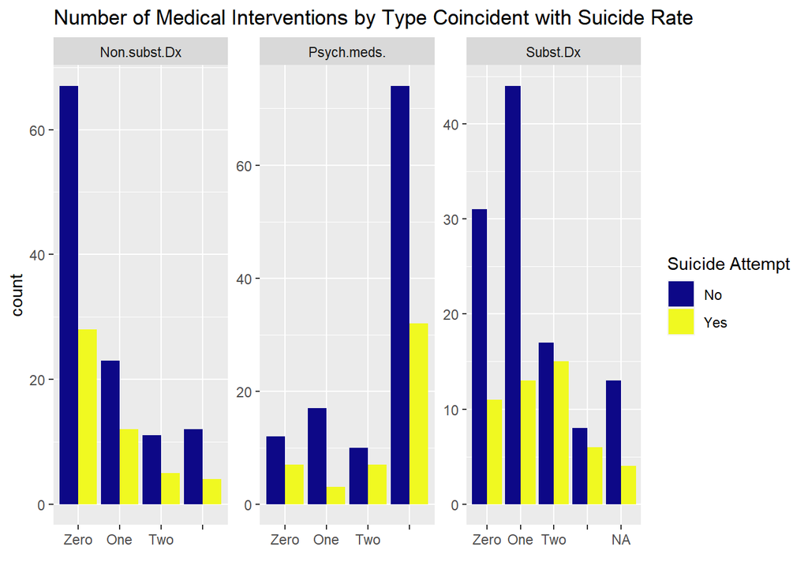

```r
# medical
df %>% filter(!is.na(Suicide)) %>%
  dplyr::select(Non.subst.Dx, Subst.Dx, Psych.meds.,Suicide) %>%
  pivot_longer(-c(Suicide)) %>%
  ggplot(aes(factor(value), fill=factor(Suicide))) +
  geom_bar(position="dodge") +
  scale_fill_viridis_d(name="Suicide Attempt",labels=c("No","Yes"), option='plasma')+
  scale_x_discrete(labels=c("Zero","One", "Two", ""))+
  labs(x="",title="Number of Medical Interventions by Type Coincident with Suicide Rate")+
  facet_wrap(~name, scales="free")
```

- Those with 2 or more substance related diagnosis tend to attempt suicide more
- Those with 1 psychotropic medication are less likely to attempt suicide

# Data Preparation and Imputation

## Imputation

First, we use predictive mean matching to impute missing data.

```r
imputed <- complete(impute <- mice(df,
                                   m = 5,
                                   method = "pmm",
                                   maxit = 5,
                                   seed = 2021,
                                   printFlag = FALSE))
```

Without missing data, new variables were created to help simplify dataset, and reduce multi-class variables to binary ones so some of the algorithms work better.

The new variables will include:

```r
processed <- imputed

# Completed highschool
processed$EDUCATION <- ifelse(imputed$Education > 12, 1,0)


# Age over 40
processed$AGE_lt40 <- ifelse(imputed$Age < 40,1,0)


# Have been abused
processed$ABUSE <- ifelse(imputed$Abuse > 0, 1,0)


#Drug use
#Going to be some colinearity here.  Use these together with caution
subs = processed[,c("Alcohol", "THC", "Cocaine", "Stimulants", "Sedative.hypnotics", "Opioids")]

processed$DRUG_abuse <- as.integer(apply(subs >= 2, 1, any))  #Drug abusers

processed$DRUG_dependence <- as.integer(apply(subs >= 3, 1, any)) #Drug dependants

processed$DRUGS <- as.integer(apply(subs >= 1, 1, any)) #Drug users

#Changes race data to white/not white.  Were only three cases of not white or african american.  0 is white, 1 is not-white
processed$Race.White <- as.integer(df$Race == 1)



#Has legal/violence issues
processed$LEGAL_issues <- ifelse(imputed$Court.order==1 | imputed$Disorderly.Conduct==1 | imputed$Hx.of.Violence==1, 1,0)

#Above Median ADHD Self Reported
processed$ADHD.gtMEDIAN <- ifelse(imputed$ADHD.Total > median(imputed$ADHD.Total), 1,0)

#Above Median MD Self Reported
processed$MD.gtMEDIAN <- ifelse(imputed$MD.TOTAL > median(imputed$MD.TOTAL), 1,0)


# Medical Intervention
processed$DX.SUBSgt2 <- ifelse(imputed$Non.subst.Dx %in% c(2,3), 1,0)


processed$PYSCHMEDSgt2 <- ifelse(imputed$Psych.meds. == 2, 1,0)
```

# Unsupervised Learning

In this section, two unsupervised learning techniques will be considered, clustering and principle component analysis.

## Clustering

*Use a clustering method to find clusters of patients here. Whether you choose to use k-means clustering or hierarchical clustering is up to you as long as you reason through your work. You are free to be creative in terms of which variables or some combination of those you want to use. Can you come up with creative names for the profiles you found? (40 points)*

Hierarchical clustering is used to find groupings of participants in the dataset based on similar characteristics. This approach is based on a matrix of distances calculated between variables. Hierarchical clustering was determined to have advantages to other clustering methods, particularly k-means clustering, for a number of reasons:

1. A value for the number of clusters does not have to be chosen
2. Results are reproducible
3. Distance based clustering is more appropriate for the binary and multinomial categorical data present in the dataset.
4. Hierarchical clustering can be considered a flexible approach since the level of granularity can be adjusted without rerunning the algorithm
5. Sub-clusters can be observed.

Processing of the raw dataset was performed to prepare for hierarchical clustering (and future analyses). Based on the EDA performed above, the number of variables of the raw dataset was reduced by combining/selecting variables of the categories identified while retaining as much of the information as possible with emphasis placed on identifying groups associated with high suicide rates. A decision was made to reduce the number of variables included in the dissimilarity matrix as much as possible and to make all variables binary so that structurally similar variables were being computed. Dimensionality reduction was helpful for obtaining more interpretable results from the clustering algorithm.

Clustering was done using the `hclust` function. A dissimilarity matrix was calculated on the binary variables using Gower distance (provided in `cluser` package), and was used as an input to the algorithm. Gower distance is better suited for binary categorical data than Euclidean or Manhattan distance which are better suited for continuous data. Final clustering was based on Ward’s linkage after attempts at other linkages (centroid, complete, etc.) produced less satisfactory results . The resulting dendrogram shows the relationship of all the data points in the system (x axis) and their associated distances (y axis). An appropriate cutoff was established based on the dendrogram below which resulted in 3 clusters. The decision to cut the dendrogram was based on the large distance between the three main branches and their closest nodes. Clusters are colored in red green and blue in dendrogram and show the cutoff point. Clustering into 3 groups gave enough granularity for purposes of identifying subgroups from the data, and was considered useful in identifying variables associated with suicide. The clusters assigned at each observation were merged dataframe and will be used as a predictor in the classification problems in a later section.

```r
# select processed variables to use for clustering
cluster_df <-  processed %>%
       dplyr::select(AGE_lt40,
                     Sex,
                     Race.White,
                     EDUCATION,
                     ADHD.gtMEDIAN,
                     MD.gtMEDIAN,
                     Hx.of.Violence,
                     DRUGS,
                     ABUSE,
                     DX.SUBSgt2,
                     PYSCHMEDSgt2,
                     Suicide
                     )

# calculate dissimilarity matrix
set.seed(9999)
distances <- daisy(cluster_df, metric = c("gower"))
```

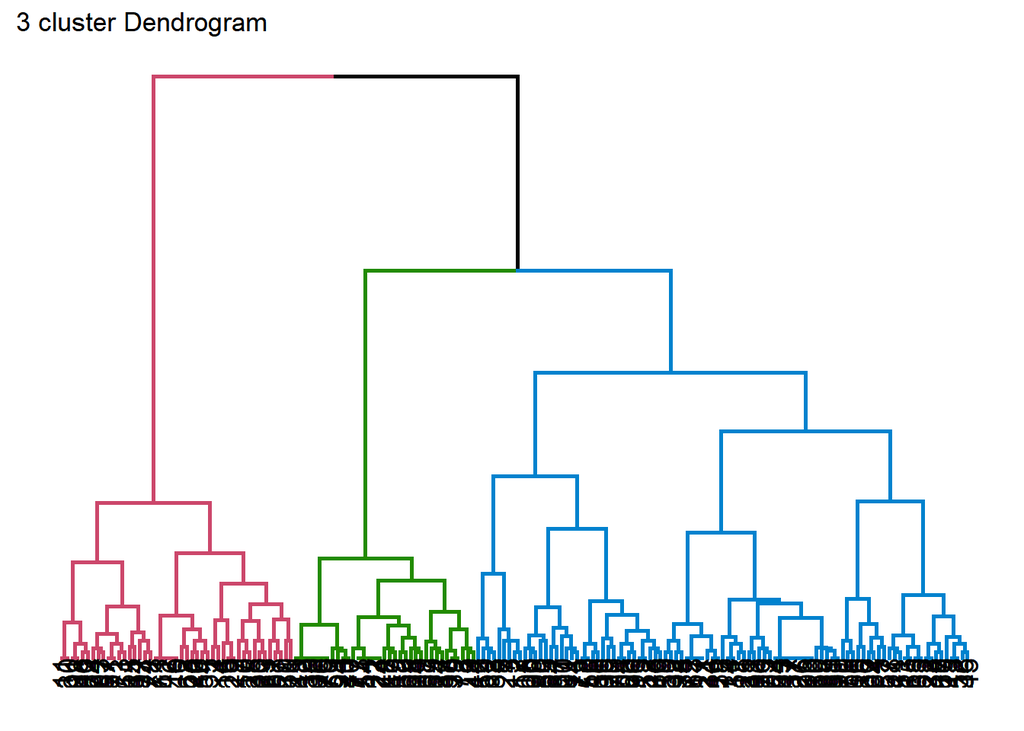

```r
# create clusters from dissimilarity matrix using hclust and wards linkage
set.seed(9999)
hclust <- hclust(distances, method="ward.D")

# plot dendrogram
as.dendrogram(hclust) %>%
  color_branches(k=3) %>%
  ggplot() +
    ggtitle("3 cluster Dendrogram")
```

```r
# assign labels back into the dataset
cluster_df$cluster <- cutree(hclust, 3)
```

Analysis of Clusters

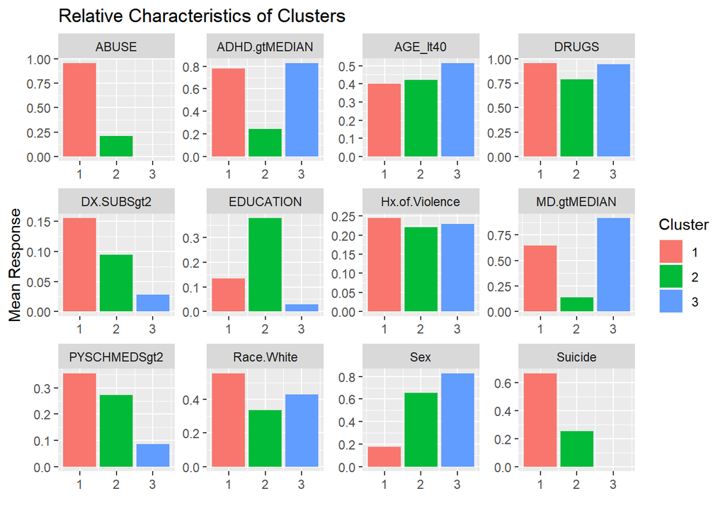

```r
#cluster_df <- update_columns(cluster_df, c(""))
table <- cluster_df %>%
  pivot_longer(-c(cluster)) %>%
  group_by(cluster, name) %>%
  summarize(mean =mean(na.omit(value))) %>%
  arrange(name)



# plot
table %>%
  ggplot(aes(y=mean,  x=cluster,fill=factor(cluster))) +
  geom_bar(stat="identity", position='dodge') +
  labs(x="",y="Mean Response", title="Relative Characteristics of Clusters")+
  facet_wrap(~name, scales="free") +
  scale_fill_discrete(name="Cluster")
```

## PCA

*Let’s try exploring this dataset using Principal Component Analysis on this dataset. You will note that there are different types of questions in the dataset: column: E-W: ADHD self-report; column X – AM: mood disorders questionnaire, column AN-AS: Individual Substance Misuse; etc. You could just use ONE of the sets of questionnaire, for example, you can conduct PCA on the ADHD score, or mood disorder score, etc. Please reason through your work as you decide on which sets of variables you want to use to conduct Principal Component Analysis. What did you learn from the PCA? Can you comment on which question may have a heavy bearing on the score? (40 points)*

Principal Component Analysis is a popular dimensionality reduction technique, where each principal component is a linear combination of the original variables. Ideally, one or a few variables will account for most of the variance in the data, allowing us to analyze the data in a lower dimension form. Below, PCA is implemented to hopefully reduce the data to a couple principal components.

PCA is generally regarded as not appropriate for analyzing categorical data (which is a major part of this dataset). However, it should work well enough for binary data. Therefore, we will only use continuous and binary data in this PCA; in preparation, several multiclass categorical variables were altered into binary variables. The dataset also comes with a couple variables (ADHD Total and MD Total) which capture the essence of many categorical variables in single continuous variables.

let’s first do a quick basic breakdown of the principal components that were created.

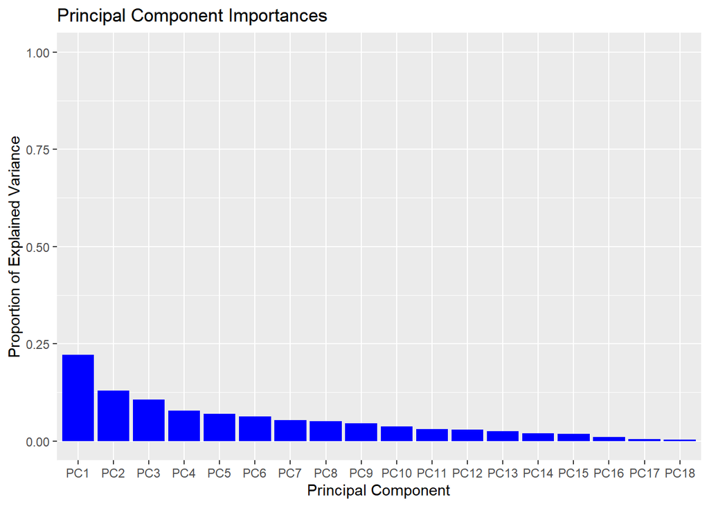

```r
set.seed("1234567890")

pca_vars <- c("Age","Sex","Race.White","ADHD.Total","MD.TOTAL","DRUG_abuse","DRUG_dependence","DRUGS","Court.order","Education","Hx.of.Violence","Disorderly.Conduct","Suicide","ABUSE","Non.subst.Dx","Psych.meds.", "DX.SUBSgt2", "PYSCHMEDSgt2")


pca_df <- processed[pca_vars]


pca <- prcomp(pca_df, scale = TRUE)  #Do PCA with scaling

q <- data.frame(summary(pca)$importance[2,]) #for the importances barplot


ggplot(data = q, aes(y = q[,1], x = reorder(row.names(q), -q[,1]))) + #Plots component importance
  geom_bar(stat = "identity", fill = "blue") +
  scale_y_continuous(limits = c(0,1)) +
  labs(title = "Principal Component Importances", y = "Proportion of Explained Variance", x = "Principal Component")
```

```r
summary(pca)
```

```
## Importance of components:
##                           PC1    PC2    PC3     PC4     PC5     PC6     PC7
## Standard deviation     1.9971 1.5281 1.3876 1.18729 1.12642 1.06733 0.98583
## Proportion of Variance 0.2216 0.1297 0.1070 0.07831 0.07049 0.06329 0.05399
## Cumulative Proportion  0.2216 0.3513 0.4583 0.53659 0.60708 0.67037 0.72436
##                            PC8    PC9   PC10    PC11    PC12    PC13    PC14
## Standard deviation     0.95319 0.9010 0.8248 0.74737 0.73005 0.67595 0.60519
## Proportion of Variance 0.05048 0.0451 0.0378 0.03103 0.02961 0.02538 0.02035
## Cumulative Proportion  0.77483 0.8199 0.8577 0.88876 0.91837 0.94376 0.96410
##                           PC15    PC16   PC17    PC18
## Standard deviation     0.56579 0.42770 0.2783 0.25620
## Proportion of Variance 0.01778 0.01016 0.0043 0.00365
## Cumulative Proportion  0.98189 0.99205 0.9963 1.00000
```

Above is a summary of each of the principal components (PCs) in this analysis. There are 18 PCs in total (one for each variable). These PCs are only weakly representative of the data individually. The first four cumulatively account for 53.7% of the variability within the data. The first PC, which explains the most, accounts for 22.2% of the variability, while PC2 accounts for 13%

Let’s see what the first four PCs are comprised of.

```r
#Took some code ad inspiration from:
#https://www.youtube.com/watch?v=0Jp4gsfOLMs

num_comps = 4

for(comp in seq(1,num_comps)) {

  #Below will return the main constituants of a principal component, and their contributions
  loading <- pca$rotation[,comp] #oing principal component 1

  ranked.scores <- sort(abs(loading), decreasing = TRUE)

  print(paste("Principal Component", comp))
  print(round(loading[names(head(ranked.scores))],3))

}
```

```
## [1] "Principal Component 1"
##      DRUG_abuse DRUG_dependence    Non.subst.Dx           DRUGS      DX.SUBSgt2
##          -0.424          -0.421           0.403          -0.368           0.321
##     Psych.meds.
##           0.242
## [1] "Principal Component 2"
##   MD.TOTAL ADHD.Total    Suicide      ABUSE Race.White        Sex
##      0.423      0.403      0.386      0.359      0.327     -0.276
## [1] "Principal Component 3"
##       PYSCHMEDSgt2        Psych.meds.     Hx.of.Violence Disorderly.Conduct
##             -0.610             -0.570             -0.267             -0.261
##              DRUGS         ADHD.Total
##             -0.188              0.180
## [1] "Principal Component 4"
##                Sex     Hx.of.Violence Disorderly.Conduct              ABUSE
##              0.493              0.457              0.381             -0.375
##         DX.SUBSgt2         Race.White
##              0.228              0.211
```

The patterns are interesting, although there is definitely some co-linearity between the variables within each PC (but not between PCs). That being said, we could try to label the first four PCs as:

PC2: Mental disorder, suicide, abuse, and white race.

PC3: Psychotropic medications and violence

PC4: Violent men and abuse.

# Supervised Learning

The objective in this section is to develop a model that predicts whether a survey participant attempted a suicide based on the information provided. Two types of classifier will be considered:

1. Support Vector Machines and
2. Stochastic Gradient Boosting.

## Gradient Boosting

*Assume you are modeling whether a patient attempted suicide (column AX). This is a binary target variable. Please use Gradient Boosting to predict whether a patient attempts suicides. Please use whatever boosting approach you deem appropriate. But please be sure to walk us through your steps. (50 points)*

Gradient boosting is an ensemble machine learning technique that has application in both regression and classification, and is typically used with decision trees. It is premised on building a sequence of weak models where each at each iteration a new tree fits the errors from the previous. For this application, a stochastic gradient boosting (SGB) model will be used. In SGB, a random sub-sample (without replacement) of variables is used at each iteration so that correlation between successive trees is reduced. Successive trees leverage this randomness to update errors of the base.

Variables to be used at predicting the target are based on the exploratory data analysis, clustering, and principle consonant analysis conducted in previous section. All categorical variables were encoded as numeric.

```r
# select variables to use for boosted model
df_boost <- processed %>%
  dplyr::select(Age,Race,Education,Sex,ADHD.Total,MD.TOTAL, LEGAL_issues,Suicide,DRUGS, ABUSE, Hx.of.Violence,PYSCHMEDSgt2,DX.SUBSgt2)
df_boost$cluster <- cutree(hclust, 3)

# change variable types if needs
df_boost <- update_columns(df_boost, c("Race","Sex", "DX.SUBSgt2","DRUGS" , "ABUSE","PYSCHMEDSgt2","Education", "LEGAL_issues", "cluster", "Hx.of.Violence"), as.factor)

#  encoding
dummy <- dummyVars(" ~ .", data=df_boost)
df_boost <- data.frame(predict(dummy, newdata = df_boost))

# remove near-zero variance
ind <- nzv(df_boost)
df_boost <- df_boost[,-ind]

# make Suicide a factor with 1 as the first level so that it becomes the "positive" class
df_boost$Suicide <- factor(df_boost$Suicide, levels=c(1,0))
```

*Splitting & Cross-validation*

20% of the dataset is split off into a test set, while the remaining 80% becomes the training set (the models are trained on this). This is done for both datasets.

Ten-fold cross validation is used as an aid in model training; this is separate from the holdout testing set, which will be used solely for model evaluation at the end of training.

```r
set.seed(1)
trainIndex <- createDataPartition(df_boost$Suicide, p = .80) %>% unlist()
training <- df_boost[ trainIndex,]
testing  <- df_boost[-trainIndex,]

# 10 fold cv
set.seed(1)
ctrl <- trainControl(method="repeatedcv",
                     number=10,
                     repeats = 3)
```

```r
# hyperparamer grid used for CV
# grid = expand.grid(.n.trees = seq(100, 2900 , by=400),
#                    .interaction.depth=seq(2,8,by=2),
#                    .shrinkage=c(0.001,0.01, 0.1),
#                    .n.minobsinnode=c(1,2,3,4))

# grid with tuned parameters
grid = expand.grid(.n.trees = 1300,
                   .interaction.depth=4,
                   .shrinkage=0.01,
                   .n.minobsinnode=1)
set.seed("1234567890")
gbm.mod2 <- train(Suicide ~ ., data=training,
                  method="gbm",
                  distribution="bernoulli",
                  #preProc=c("center","scale"),
                  tuneGrid = grid,
                  trControl=ctrl,
                  verbose=F)

# make predictions on test set
gbm.predict <- predict(gbm.mod2, newdata = testing %>% dplyr::select(-Suicide))
#gbm.mod2

# plot results of cross validation
#plot(gbm.mod2)

# Confusion matrix
confusionMatrix(gbm.predict, testing$Suicide)
```

```
## Confusion Matrix and Statistics
##
##           Reference
## Prediction  1  0
##          1  7  4
##          0  3 20
##
##                Accuracy : 0.7941
##                  95% CI : (0.621, 0.913)
##     No Information Rate : 0.7059
##     P-Value [Acc > NIR] : 0.1741
##
##                   Kappa : 0.5182
##
##  Mcnemar's Test P-Value : 1.0000
##
##             Sensitivity : 0.7000
##             Specificity : 0.8333
##          Pos Pred Value : 0.6364
##          Neg Pred Value : 0.8696
##              Prevalence : 0.2941
##          Detection Rate : 0.2059
##    Detection Prevalence : 0.3235
##       Balanced Accuracy : 0.7667
##
##        'Positive' Class : 1
##
```

## Support Vector Machine

*Using the same target variable (suicide attempt), please use support vector machine to model this. You might want to consider reducing the number of variables or somehow use extracted information from the variables. This can be a really fun modeling task! (50 points)*

SVMs are fairly robust. The data doesn’t need to be linear, but multiclass independent variables won’t work that well. We’ll use some of our pre-distilled variables here so we can avoid that issue without dramatically increasing the number of classes via dummy encoding (which was briefly attempted with no success). Below, the data is processed and split into training and testing sets (80/20%).

```r
set.seed("1234567890")


svm_vars = c("Age","Sex","Race.White","ADHD.Total","MD.TOTAL","DRUG_abuse","DRUG_dependence","DRUGS","Court.order","Education","Hx.of.Violence","Disorderly.Conduct","Suicide","ABUSE","Non.subst.Dx","Psych.meds.", "DX.SUBSgt2", "PYSCHMEDSgt2")


#select the variables
svm_df <- processed[svm_vars]

#Change suicide to factor
svm_df$Suicide <- as.factor(svm_df$Suicide)

#Train test split
splitdex <- createDataPartition(svm_df$Suicide, p = 0.8, list = FALSE)
train <- svm_df[splitdex,]
test <- svm_df[-splitdex,]
```

There are many variations of support vector machines; we’ll try a few of them. Below, one with a linear kernel is used. The only hyper-parameter to tune here is cost, which is essentially the margins by which support vectors are selected. Low cost means smoother decision surfaces, while high cost tends to select more support vectors. ‘Linear’ here basically means it won’t use a kernel trick to map data to a higher dimension.

```r
set.seed("1234567890")

grid = expand.grid(cost = seq(1,10, length.out = 20)^2)
svm.linear.fit <- train(Suicide ~.,
                 data = train,
                 method = "svmLinear2",             #SVM with linear kernel from the e1071 package
                 preProcess = c("center","scale"),
                 tuneGrid = grid)


svm.linear.fit
```

```
## Support Vector Machines with Linear Kernel
##
## 141 samples
##  17 predictor
##   2 classes: '0', '1'
##
## Pre-processing: centered (17), scaled (17)
## Resampling: Bootstrapped (25 reps)
## Summary of sample sizes: 141, 141, 141, 141, 141, 141, ...
## Resampling results across tuning parameters:
##
##   cost        Accuracy   Kappa
##     1.000000  0.6751739  0.1856785
##     2.171745  0.6733364  0.1850818
##     3.792244  0.6701639  0.1809040
##     5.861496  0.6668974  0.1737016
##     8.379501  0.6628804  0.1661662
##    11.346260  0.6645186  0.1712269
##    14.761773  0.6645186  0.1712269
##    18.626039  0.6631694  0.1672205
##    22.939058  0.6640205  0.1698029
##    27.700831  0.6647897  0.1713664
##    32.911357  0.6640754  0.1702014
##    38.570637  0.6631316  0.1689307
##    44.678670  0.6624173  0.1677834
##    51.235457  0.6615284  0.1660466
##    58.240997  0.6615284  0.1660466
##    65.695291  0.6615284  0.1660466
##    73.598338  0.6615284  0.1660466
##    81.950139  0.6615284  0.1660466
##    90.750693  0.6615284  0.1660466
##   100.000000  0.6615284  0.1660466
##
## Accuracy was used to select the optimal model using the largest value.
## The final value used for the model was cost = 1.
```

```r
svm.linear.predictions <- predict(svm.linear.fit, test)


confusionMatrix(svm.linear.predictions, test$Suicide, positive = "1")
```

```
## Confusion Matrix and Statistics
##
##           Reference
## Prediction  0  1
##          0 21  6
##          1  3  4
##
##                Accuracy : 0.7353
##                  95% CI : (0.5564, 0.8712)
##     No Information Rate : 0.7059
##     P-Value [Acc > NIR] : 0.4355
##
##                   Kappa : 0.3014
##
##  Mcnemar's Test P-Value : 0.5050
##
##             Sensitivity : 0.4000
##             Specificity : 0.8750
##          Pos Pred Value : 0.5714
##          Neg Pred Value : 0.7778
##              Prevalence : 0.2941
##          Detection Rate : 0.1176
##    Detection Prevalence : 0.2059
##       Balanced Accuracy : 0.6375
##
##        'Positive' Class : 1
##
```

Above is the breakdown of the model, and it’s performance on a holdout set. A cost value of 1 was chosen. This produces a mix of false/true positives/negatives, with an outsized amount of false negatives. Unfortunately, it’s prediction accuracy on the test set is close to the no-information rate, and not significantly different at $\alpha$ = 0.05. Also, although this model have a high specificity (true negative rate), due to the nature of suicide prediction (and the implied impetus to interdict), it would be more desirable to have a high sensitivity (true positive rate).

Not shown above, however, are previous attempts where lower cost values were considered. It was found when presented with cost values under 1, the lowest cost values were always chosen, resulting in models that only predicted the most common class (no suicide); the no information rate. These models were deemed less useful despite having similar overall accuracy (they had 0 sensitivity)

Below a SVM model with a polynomial kernel is attempted.

```r
set.seed("1234567890")

grid = expand.grid(C = seq(1, 5, length.out = 3)^2,
                   degree = seq(1,5, 1),
                   scale = seq(1, 5, length.out = 3)^2)


svm.poly.fit <- train(Suicide ~.,
                 data = train,
                 method = "svmPoly",             #SVM with polynomial kernel from the kernlab package
                 preProcess = c("center","scale"),
                 tuneGrid = grid)


svm.poly.fit
```

```
## Support Vector Machines with Polynomial Kernel
##
## 141 samples
##  17 predictor
##   2 classes: '0', '1'
##
## Pre-processing: centered (17), scaled (17)
## Resampling: Bootstrapped (25 reps)
## Summary of sample sizes: 141, 141, 141, 141, 141, 141, ...
## Resampling results across tuning parameters:
##
##   C   degree  scale  Accuracy   Kappa
##    1  1        1     0.6751739  0.18567850
##    1  1        9     0.6629445  0.16741122
##    1  1       25     0.6640205  0.16980293
```

[output cut: 45 more lines]

```r
svm.poly.predictions <- predict(svm.poly.fit, test)


confusionMatrix(svm.poly.predictions, test$Suicide, positive = "1")
```

```
## Confusion Matrix and Statistics
##
##           Reference
## Prediction  0  1
##          0 21  6
##          1  3  4
##
##                Accuracy : 0.7353
##                  95% CI : (0.5564, 0.8712)
##     No Information Rate : 0.7059
##     P-Value [Acc > NIR] : 0.4355
##
##                   Kappa : 0.3014
##
##  Mcnemar's Test P-Value : 0.5050
##
##             Sensitivity : 0.4000
##             Specificity : 0.8750
##          Pos Pred Value : 0.5714
##          Neg Pred Value : 0.7778
##              Prevalence : 0.2941
##          Detection Rate : 0.1176
##    Detection Prevalence : 0.2059
##       Balanced Accuracy : 0.6375
##
##        'Positive' Class : 1
##
```

Unfortunately, the results for this one are the same as the SVM model with a linear kernel. This model has two additional hyper-parameters in addition to cost: the degree of the polynomial, and a scalar. Increasing both of these should make for more precise separations. This only chooses a degree, scale, and cost of 1; the lowest available.

Below we’ll try a SVM with a radial kernel, which will map to a higher dimension using kernel trick and hyper-parameters cost, and sigma which will lead to more complicated separations

```r
set.seed("1234567890")

grid = expand.grid(C = seq(1, 5, length.out = 5)^2,
                   sigma = seq(.1,10, length.out = 5)^2)


svm.rad.fit <- train(Suicide ~.,
                 data = train,
                 method = "svmRadial",             #SVM with radial kernel from the kernlab package
                 preProcess = c("center","scale"),
                 tuneGrid = grid)


svm.rad.fit
```

```
## Support Vector Machines with Radial Basis Function Kernel
##
## 141 samples
##  17 predictor
##   2 classes: '0', '1'
##
## Pre-processing: centered (17), scaled (17)
## Resampling: Bootstrapped (25 reps)
## Summary of sample sizes: 141, 141, 141, 141, 141, 141, ...
## Resampling results across tuning parameters:
##
##   C   sigma       Accuracy   Kappa
##    1    0.010000  0.6884360  0.06925074
##    1    6.630625  0.6897054  0.03450332
##    1   25.502500  0.6849801  0.01218744
```

[output cut: 25 more lines]

```r
svm.rad.predictions <- predict(svm.rad.fit, test)


confusionMatrix(svm.rad.predictions, test$Suicide, positive = "1")
```

```
## Confusion Matrix and Statistics
##
##           Reference
## Prediction  0  1
##          0 24 10
##          1  0  0
##
##                Accuracy : 0.7059
##                  95% CI : (0.5252, 0.849)
##     No Information Rate : 0.7059
##     P-Value [Acc > NIR] : 0.584308
##
##                   Kappa : 0
##
##  Mcnemar's Test P-Value : 0.004427
##
##             Sensitivity : 0.0000
##             Specificity : 1.0000
##          Pos Pred Value :    NaN
##          Neg Pred Value : 0.7059
##              Prevalence : 0.2941
##          Detection Rate : 0.0000
##    Detection Prevalence : 0.0000
##       Balanced Accuracy : 0.5000
##
##        'Positive' Class : 1
##
```

This model chooses a sigma of ~6.6 and lowest cost (1), and guesses the negative class (no-suicide) for each testing sample. It performs at the no-information rate, and is not useful.

I suspect this data is not well separable, which may be impacting the performance of these SVM models. Also, because the dataset is fairly unbalanced, we would need an overall accuracy of over 85-87% for these model to be significantly better than guessing ‘no suicide’ in each instance; this would likely prove difficult with this dataset even given optimal pre-processing an feature engineering.